# CC

## Importing Required Modules

```python
import pandas as pd
import seaborn as sns
import matplotlib.pyplot as plt
import numpy as np
import warnings
warnings.filterwarnings('ignore')
%matplotlib inline
```

## Loading Dataset

```python
df=pd.read_csv('https://raw.githubusercontent.com/Prasfur/CC-IP-Live-Project/master/DS_DATESET.csv')
df.head()
```

|  | First Name | Last Name | City | State | Zip Code | DOB [DD/MM/YYYY] | Age | Gender | Email Address | Contact Number | ... | Programming Language Known other than Java (one major) | Have you worked on MySQL or Oracle database | Have you studied OOP Concepts | Certifications/Achievement/ Research papers | Rate your written communication skills [1-10] | Rate your verbal communication skills [1-10] | Link to updated Resume (Google/ One Drive link preferred) | link to Linkedin profile | How Did You Hear About This Internship? | Label |
| --- | --- | --- | --- | --- | --- | --- | --- | --- | --- | --- | --- | --- | --- | --- | --- | --- | --- | --- | --- | --- | --- |
| 0 | Barron | Harnes | Kolhapur | Maharashtra | 416004 | 24/09/2000 | 19 | Male | bharnes0@harvard.edu | 6345186600 | ... | HTML/CSS | Yes | No | NaN | 6 | 10 | NaN | NaN | Twitter | ineligible |
| 1 | Velma | Allone | Pune | Maharashtra | 411011 | 23/10/1997 | 22 | Female | vallone1@i2i.jp | 2808753102 | ... | PHP | No | Yes | NaN | 10 | 7 | NaN | NaN | Ex/Current Employee | eligible |
| 2 | Thibaut | Scotland | Mumbai | Maharashtra | 400059 | 6/2/1996 | 24 | Male | tscotland2@opensource.org | 2945231918 | ... | C | No | No | NaN | 8 | 6 | NaN | NaN | Twitter | ineligible |
| 3 | Retha | Proud | Solapur | Maharashtra | 413224 | 26/12/1999 | 20 | Female | rproud3@flavors.me | 7507196200 | ... | PHP | No | Yes | NaN | 9 | 6 | NaN | NaN | Twitter | ineligible |
| 4 | Del | Pearse | Sangli | Maharashtra | 416436 | 21/09/1996 | 23 | Female | dpearse4@sakura.ne.jp | 6643884281 | ... | Python | No | Yes | NaN | 8 | 6 | NaN | NaN | Facebook | ineligible |

5 rows × 32 columns

# Data Analysis

### Size of dataset

```python
print("Number of rows:",df.shape[0])
print("Number of columns:",df.shape[1])
```

```
Number of rows: 10000
Number of columns: 32
```

```python
df.columns
```

```
Index(['First Name', 'Last Name', 'City', 'State', 'Zip Code',
       'DOB [DD/MM/YYYY]', 'Age', 'Gender', 'Email Address', 'Contact Number',
       'Emergency Contact Number', 'College name', 'University Name', 'Degree',
       'Major/Area of Study', 'Course Type', 'Which-year are you studying in?',
       'CGPA/ percentage', 'Expected Graduation-year', 'Areas of interest',
       'Current Employment Status', 'Have you worked core Java',
       'Programming Language Known other than Java (one major)',
       'Have you worked on MySQL or Oracle database',
       'Have you studied OOP Concepts',
       'Certifications/Achievement/ Research papers',
       'Rate your written communication skills [1-10]',
       'Rate your verbal communication skills [1-10]',
       'Link to updated Resume (Google/ One Drive link preferred)',
       'link to Linkedin profile', 'How Did You Hear About This Internship?',
       'Label'],
      dtype='object')
```

```python
df.dtypes
```

```
First Name                                                    object
Last Name                                                     object
City                                                          object
State                                                         object
Zip Code                                                       int64
DOB [DD/MM/YYYY]                                              object
Age                                                            int64
Gender                                                        object
Email Address                                                 object
Contact Number                                                 int64
Emergency Contact Number                                       int64
College name                                                  object
University Name                                               object
Degree                                                        object
Major/Area of Study                                           object
Course Type                                                   object
Which-year are you studying in?                               object
CGPA/ percentage                                             float64
Expected Graduation-year                                       int64
Areas of interest                                             object
Current Employment Status                                     object
Have you worked core Java                                     object
Programming Language Known other than Java (one major)        object
Have you worked on MySQL or Oracle database                   object
Have you studied OOP Concepts                                 object
Certifications/Achievement/ Research papers                  float64
Rate your written communication skills [1-10]                  int64
Rate your verbal communication skills [1-10]                   int64
Link to updated Resume (Google/ One Drive link preferred)    float64
link to Linkedin profile                                     float64
How Did You Hear About This Internship?                       object
Label                                                         object
dtype: object
```

```python
df.info()
```

```
<class 'pandas.core.frame.DataFrame'>
RangeIndex: 10000 entries, 0 to 9999
Data columns (total 32 columns):
 #   Column                                                     Non-Null Count  Dtype
---  ------                                                     --------------  -----
 0   First Name                                                 10000 non-null  object
 1   Last Name                                                  10000 non-null  object
 2   City                                                       10000 non-null  object
 3   State                                                      10000 non-null  object
 4   Zip Code                                                   10000 non-null  int64
 5   DOB [DD/MM/YYYY]                                           10000 non-null  object
 6   Age                                                        10000 non-null  int64
 7   Gender                                                     10000 non-null  object
 8   Email Address                                              10000 non-null  object
 9   Contact Number                                             10000 non-null  int64
```

[output cut: 24 more lines]

```python
df.describe()
```

|  | Zip Code | Age | Contact Number | Emergency Contact Number | CGPA/ percentage | Expected Graduation-year | Certifications/Achievement/ Research papers | Rate your written communication skills [1-10] | Rate your verbal communication skills [1-10] | Link to updated Resume (Google/ One Drive link preferred) | link to Linkedin profile |
| --- | --- | --- | --- | --- | --- | --- | --- | --- | --- | --- | --- |
| count | 10000.000000 | 10000.000000 | 1.000000e+04 | 1.000000e+04 | 10000.000000 | 10000.000000 | 0.0 | 10000.000000 | 10000.000000 | 0.0 | 0.0 |
| mean | 410087.514700 | 21.384700 | 5.521004e+09 | 5.569675e+09 | 8.500260 | 2021.509300 | NaN | 7.988400 | 7.995500 | NaN | NaN |
| std | 6408.897346 | 1.489674 | 2.622215e+09 | 2.581596e+09 | 0.860161 | 1.116888 | NaN | 1.413529 | 1.419113 | NaN | NaN |
| min | 400012.000000 | 19.000000 | 6.402026e+06 | 1.001359e+09 | 7.000000 | 2020.000000 | NaN | 6.000000 | 6.000000 | NaN | NaN |
| 25% | 400701.000000 | 20.000000 | 3.191651e+09 | 3.353914e+09 | 7.750000 | 2021.000000 | NaN | 7.000000 | 7.000000 | NaN | NaN |
| 50% | 413001.000000 | 21.000000 | 5.543699e+09 | 5.634072e+09 | 8.500000 | 2022.000000 | NaN | 8.000000 | 8.000000 | NaN | NaN |
| 75% | 416004.000000 | 23.000000 | 7.796677e+09 | 7.794617e+09 | 9.232500 | 2023.000000 | NaN | 9.000000 | 9.000000 | NaN | NaN |
| max | 416436.000000 | 24.000000 | 9.999767e+09 | 9.999852e+09 | 10.000000 | 2023.000000 | NaN | 10.000000 | 10.000000 | NaN | NaN |

# 1. Preprocessing the data for missing values, unknown values, encoding categorical values

## Data Cleaning

### Checking for Null and NaN Values

```python
df.isnull().sum()
```

```
First Name                                                       0
Last Name                                                        0
City                                                             0
State                                                            0
Zip Code                                                         0
DOB [DD/MM/YYYY]                                                 0
Age                                                              0
Gender                                                           0
Email Address                                                    0
Contact Number                                                   0
Emergency Contact Number                                         0
College name                                                     0
University Name                                                  0
Degree                                                           0
Major/Area of Study                                              0
Course Type                                                      0
Which-year are you studying in?                                  0
CGPA/ percentage                                                 0
Expected Graduation-year                                         0
Areas of interest                                                0
Current Employment Status                                        0
Have you worked core Java                                        0
Programming Language Known other than Java (one major)           0
Have you worked on MySQL or Oracle database                      0
Have you studied OOP Concepts                                    0
Certifications/Achievement/ Research papers                  10000
Rate your written communication skills [1-10]                    0
Rate your verbal communication skills [1-10]                     0
Link to updated Resume (Google/ One Drive link preferred)    10000
link to Linkedin profile                                     10000
How Did You Hear About This Internship?                          0
Label                                                            0
dtype: int64
```

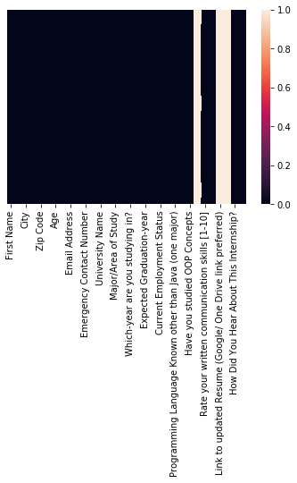

```python
sns.heatmap(df.isnull(),yticklabels=False)
plt.show()
```

### Eliminating columns with NaN values

```python
df = df.dropna(axis=1)
```

```python
df.isnull().sum()
```

```
First Name                                                0
Last Name                                                 0
City                                                      0
State                                                     0
Zip Code                                                  0
DOB [DD/MM/YYYY]                                          0
Age                                                       0
Gender                                                    0
Email Address                                             0
Contact Number                                            0
Emergency Contact Number                                  0
College name                                              0
University Name                                           0
Degree                                                    0
Major/Area of Study                                       0
Course Type                                               0
Which-year are you studying in?                           0
CGPA/ percentage                                          0
Expected Graduation-year                                  0
Areas of interest                                         0
Current Employment Status                                 0
Have you worked core Java                                 0
Programming Language Known other than Java (one major)    0
Have you worked on MySQL or Oracle database               0
Have you studied OOP Concepts                             0
Rate your written communication skills [1-10]             0
Rate your verbal communication skills [1-10]              0
How Did You Hear About This Internship?                   0
Label                                                     0
dtype: int64
```

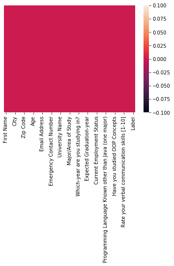

```python
sns.heatmap(df.isnull(),yticklabels=False)
plt.show()
```

```python
print("Number of rows after removing Null values:",df.shape[0])
print("Number of columns after removing Null values:",df.shape[1])
```

```
Number of rows after removing Null values: 10000
Number of columns after removing Null values: 29
```

```python
df.isnull()
```

|  | First Name | Last Name | City | State | Zip Code | DOB [DD/MM/YYYY] | Age | Gender | Email Address | Contact Number | ... | Areas of interest | Current Employment Status | Have you worked core Java | Programming Language Known other than Java (one major) | Have you worked on MySQL or Oracle database | Have you studied OOP Concepts | Rate your written communication skills [1-10] | Rate your verbal communication skills [1-10] | How Did You Hear About This Internship? | Label |
| --- | --- | --- | --- | --- | --- | --- | --- | --- | --- | --- | --- | --- | --- | --- | --- | --- | --- | --- | --- | --- | --- |
| 0 | False | False | False | False | False | False | False | False | False | False | ... | False | False | False | False | False | False | False | False | False | False |
| 1 | False | False | False | False | False | False | False | False | False | False | ... | False | False | False | False | False | False | False | False | False | False |
| 2 | False | False | False | False | False | False | False | False | False | False | ... | False | False | False | False | False | False | False | False | False | False |
| 3 | False | False | False | False | False | False | False | False | False | False | ... | False | False | False | False | False | False | False | False | False | False |
| 4 | False | False | False | False | False | False | False | False | False | False | ... | False | False | False | False | False | False | False | False | False | False |
| ... | ... | ... | ... | ... | ... | ... | ... | ... | ... | ... | ... | ... | ... | ... | ... | ... | ... | ... | ... | ... | ... |
| 9995 | False | False | False | False | False | False | False | False | False | False | ... | False | False | False | False | False | False | False | False | False | False |
| 9996 | False | False | False | False | False | False | False | False | False | False | ... | False | False | False | False | False | False | False | False | False | False |
| 9997 | False | False | False | False | False | False | False | False | False | False | ... | False | False | False | False | False | False | False | False | False | False |
| 9998 | False | False | False | False | False | False | False | False | False | False | ... | False | False | False | False | False | False | False | False | False | False |
| 9999 | False | False | False | False | False | False | False | False | False | False | ... | False | False | False | False | False | False | False | False | False | False |

10000 rows × 29 columns

# 2.a The number of students applied to different technologies

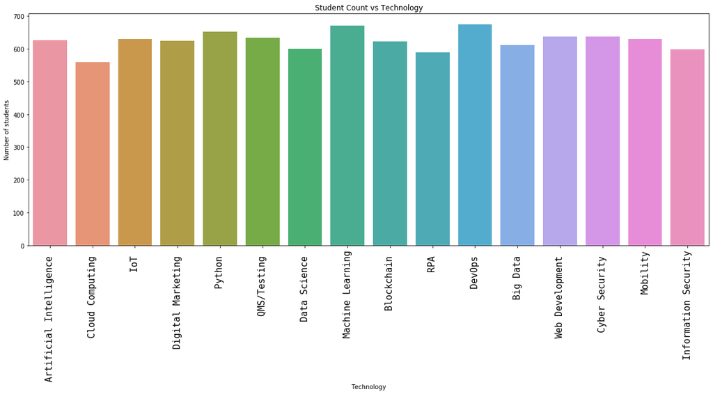

```
Counts:
```

```
DevOps                      674
Machine Learning            671
Python                      652
Cyber Security              638
Web Development             637
QMS/Testing                 633
Mobility                    631
IoT                         630
Artificial Intelligence     627
Digital Marketing           624
Blockchain                  623
Big Data                    612
Data Science                601
Information Security        598
RPA                         589
Cloud Computing             560
Name: Areas of interest, dtype: int64
```

```python
plt.figure(figsize=(20, 7))
sns.countplot(df['Areas of interest'])
plt.title('Student Count vs Technology')
plt.xlabel('Technology')
plt.xticks(rotation=90,fontsize=15,fontname='monospace')
plt.ylabel('Number of students')
plt.show()
print("Counts:")
df['Areas of interest'].value_counts()
```

# 2.b The number of students applied for Data Science who knew ‘’Python” and who didn’t

```python
DS=df[df['Areas of interest']=='Data Science ']
DSp=DS[DS['Programming Language Known other than Java (one major)']=='Python']
DSnp=DS[DS['Programming Language Known other than Java (one major)']!='Python']
DSnp['Programming Language Known other than Java (one major)']='Not Python'
DSp=DSp.append(DSnp)
```

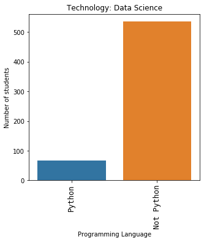

```
Counts:
```

```
Not Python    535
Python         66
Name: Programming Language Known other than Java (one major), dtype: int64
```

```python
plt.figure(figsize=(5,5))
sns.countplot(DSp['Programming Language Known other than Java (one major)'])
plt.title('Technology: Data Science')
plt.xlabel('Programming Language')
plt.xticks(rotation=90,fontsize=12,fontname='monospace')
plt.ylabel('Number of students')
plt.show()
print("Counts:")
DSp['Programming Language Known other than Java (one major)'].value_counts()
```

# 2.c The different ways students learned about this program

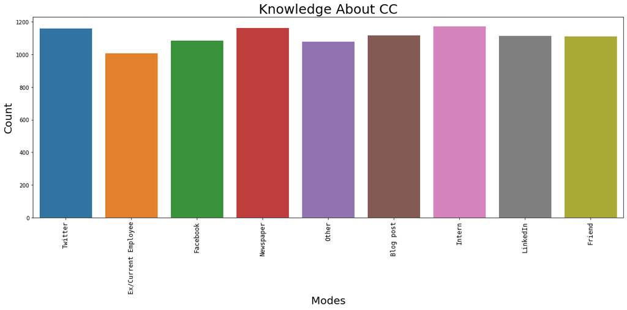

```
Counts:
```

```
Intern                 1173
Newspaper              1162
Twitter                1160
Blog post              1116
LinkedIn               1112
Friend                 1109
Facebook               1084
Other                  1077
Ex/Current Employee    1007
Name: How Did You Hear About This Internship?, dtype: int64
```

```python
plt.figure(figsize=(20,7))
sns.countplot(df['How Did You Hear About This Internship?'])
plt.title('Knowledge About CC',fontsize=25)
plt.xlabel('Modes',fontsize=20)
plt.xticks(rotation=90,fontsize=12,fontname='monospace')
plt.ylabel('Count',fontsize=20)
plt.show()
print("Counts:")
df['How Did You Hear About This Internship?'].value_counts()
```

# 2.d Students who are in the fourth year and have a CGPA greater than 8.0

```python
fy8=df[(df['Which-year are you studying in?']=='Fourth-year') & (df['CGPA/ percentage']>8)]
print("Total students in fourth year and CGPA above 8.0:",len(fy8))
fy8.head()
```

```
Total students in fourth year and CGPA above 8.0: 1697
```

|  | First Name | Last Name | City | State | Zip Code | DOB [DD/MM/YYYY] | Age | Gender | Email Address | Contact Number | ... | Areas of interest | Current Employment Status | Have you worked core Java | Programming Language Known other than Java (one major) | Have you worked on MySQL or Oracle database | Have you studied OOP Concepts | Rate your written communication skills [1-10] | Rate your verbal communication skills [1-10] | How Did You Hear About This Internship? | Label |
| --- | --- | --- | --- | --- | --- | --- | --- | --- | --- | --- | --- | --- | --- | --- | --- | --- | --- | --- | --- | --- | --- |
| 1 | Velma | Allone | Pune | Maharashtra | 411011 | 23/10/1997 | 22 | Female | vallone1@i2i.jp | 2808753102 | ... | Cloud Computing | Student | Yes | PHP | No | Yes | 10 | 7 | Ex/Current Employee | eligible |
| 2 | Thibaut | Scotland | Mumbai | Maharashtra | 400059 | 6/2/1996 | 24 | Male | tscotland2@opensource.org | 2945231918 | ... | IoT | Student | Yes | C | No | No | 8 | 6 | Twitter | ineligible |
| 5 | Farlay | Anstis | Sangli | Maharashtra | 416415 | 12/2/2000 | 20 | Male | fanstis5@zdnet.com | 8429984749 | ... | Python | Student | Yes | PHP | Yes | No | 6 | 7 | Twitter | ineligible |
| 8 | Stanwood | Ferron | Mumbai | Maharashtra | 400055 | 9/12/1999 | 20 | Male | sferron8@vkontakte.ru | 8739225175 | ... | QMS/Testing | Student | No | C++ | Yes | Yes | 9 | 10 | Other | eligible |
| 12 | Adelaide | Trebilcock | Sangli | Maharashtra | 416436 | 16/11/1998 | 21 | Female | atrebilcockc@flickr.com | 7356902004 | ... | RPA | Student | No | PHP | Yes | No | 8 | 6 | Other | ineligible |

5 rows × 29 columns

### Some insightful visualizations for students in fourth year and with CGPA above 8.0

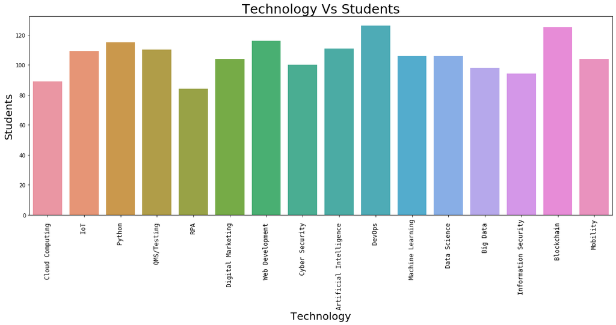

```
Counts:
```

```
DevOps                      126
Blockchain                  125
Web Development             116
Python                      115
Artificial Intelligence     111
QMS/Testing                 110
IoT                         109
Machine Learning            106
Data Science                106
Mobility                    104
Digital Marketing           104
Cyber Security              100
Big Data                     98
Information Security         94
Cloud Computing              89
RPA                          84
Name: Areas of interest, dtype: int64
```

```python
plt.figure(figsize=(20,7))
sns.countplot(fy8['Areas of interest'])
plt.title('Technology Vs Students',fontsize=25)
plt.xlabel('Technology',fontsize=20)
plt.xticks(rotation=90,fontsize=12,fontname='monospace')
plt.ylabel('Students',fontsize=20)
plt.show()
print("Counts:")
fy8['Areas of interest'].value_counts()
```

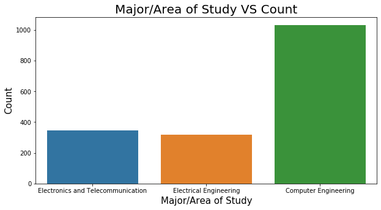

```
Counts:
```

```
Computer Engineering                 1032
Electronics and Telecommunication     345
Electrical Engineering                320
Name: Major/Area of Study, dtype: int64
```

```python
plt.figure(figsize=(10,5))
sns.countplot(fy8['Major/Area of Study'])
plt.title('Major/Area of Study VS Count',fontsize=20)
plt.xlabel('Major/Area of Study',fontsize=15)
plt.ylabel('Count',fontsize=15)
plt.show()
print("Counts:")
fy8['Major/Area of Study'].value_counts()
```

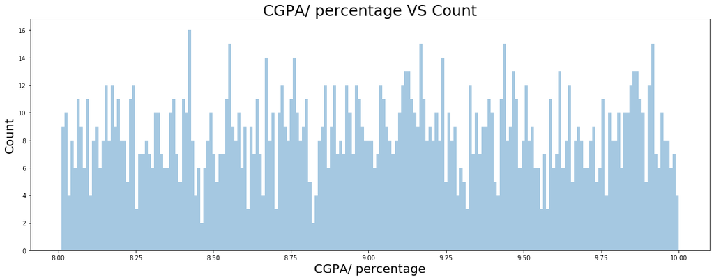

```
Counts:
```

```
8.42    16
9.92    15
8.55    15
9.44    15
9.17    15
        ..
9.58     3
9.56     3
8.25     3
8.82     2
8.46     2
Name: CGPA/ percentage, Length: 200, dtype: int64
```

```python
plt.figure(figsize=(20,7))
sns.distplot(fy8['CGPA/ percentage'],bins=200,kde=False)
plt.title('CGPA/ percentage VS Count',fontsize=25)
plt.xlabel('CGPA/ percentage',fontsize=20)
plt.ylabel('Count',fontsize=20)
plt.show()
print("Counts:")
fy8['CGPA/ percentage'].value_counts()
```

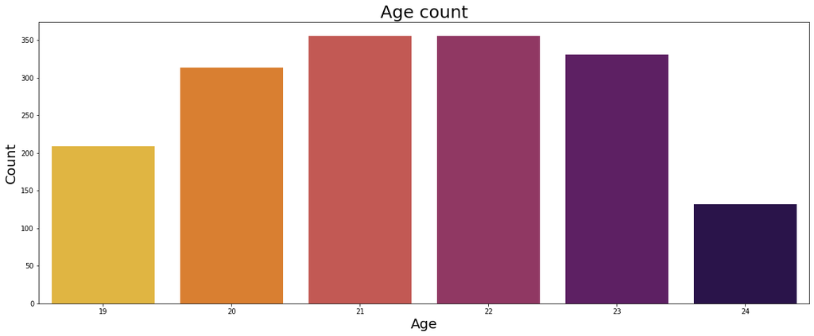

```
Counts:
```

```
22    356
21    356
23    331
20    313
19    209
24    132
Name: Age, dtype: int64
```

```python
plt.figure(figsize=(20,7.5))
sns.countplot(fy8['Age'],palette='inferno_r')
plt.title('Age count',fontsize=25)
plt.xlabel('Age',fontsize=20)
plt.ylabel('Count',fontsize=20)
plt.show()
print("Counts:")
fy8['Age'].value_counts()
```

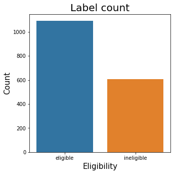

```
Counts:
```

```
eligible      1092
ineligible     605
Name: Label, dtype: int64
```

```python
plt.figure(figsize=(5,5))
sns.countplot(fy8['Label'])
plt.title('Label count',fontsize=20)
plt.xlabel('Eligibility',fontsize=15)
plt.ylabel('Count',fontsize=15)
plt.show()
print("Counts:")
fy8['Label'].value_counts()
```

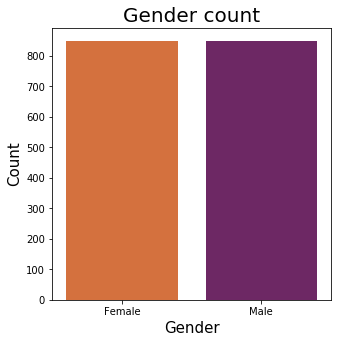

```
Counts:
```

```
Female    849
Male      848
Name: Gender, dtype: int64
```

```python
plt.figure(figsize=(5,5))
sns.countplot(fy8['Gender'],palette='inferno_r')
plt.title('Gender count',fontsize=20)
plt.xlabel('Gender',fontsize=15)
plt.ylabel('Count',fontsize=15)
plt.show()
print("Counts:")
fy8['Gender'].value_counts()
```

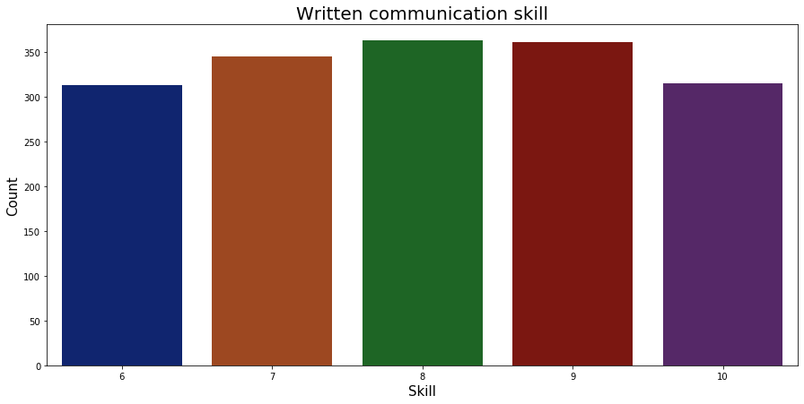

```
Counts:
```

```
8     363
9     361
7     345
10    315
6     313
Name: Rate your written communication skills [1-10], dtype: int64
```

```python
plt.figure(figsize=(15,7))
sns.countplot(fy8['Rate your written communication skills [1-10]'],palette='dark')
plt.title('Written communication skill',fontsize=20)
plt.xlabel('Skill',fontsize=15)
plt.ylabel('Count',fontsize=15)
plt.show()
print("Counts:")
fy8['Rate your written communication skills [1-10]'].value_counts()
```

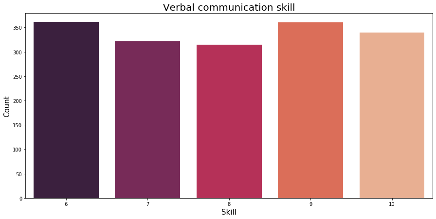

```
Counts:
```

```
6     361
9     360
10    339
7     322
8     315
Name: Rate your verbal communication skills [1-10], dtype: int64
```

```python
plt.figure(figsize=(15,7))
sns.countplot(fy8['Rate your verbal communication skills [1-10]'],palette='rocket')
plt.title('Verbal communication skill',fontsize=20)
plt.xlabel('Skill',fontsize=15)
plt.ylabel('Count',fontsize=15)
plt.show()
print("Counts:")
fy8['Rate your verbal communication skills [1-10]'].value_counts()
```

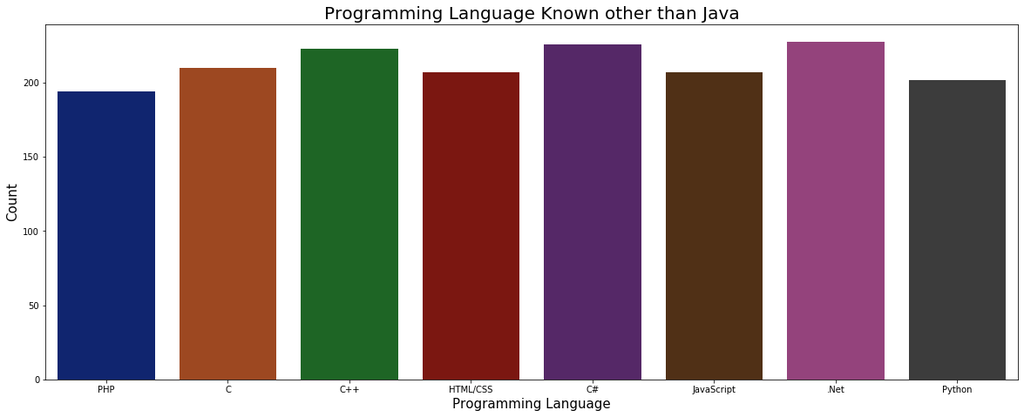

```
Counts:
```

```
.Net          228
C#            226
C++           223
C             210
JavaScript    207
HTML/CSS      207
Python        202
PHP           194
Name: Programming Language Known other than Java (one major), dtype: int64
```

```python
plt.figure(figsize=(20,7.5))
sns.countplot(fy8['Programming Language Known other than Java (one major)'],palette='dark')
plt.title('Programming Language Known other than Java',fontsize=20)
plt.xlabel('Programming Language',fontsize=15)
plt.ylabel('Count',fontsize=15)
plt.show()
print("Counts:")
fy8['Programming Language Known other than Java (one major)'].value_counts()
```

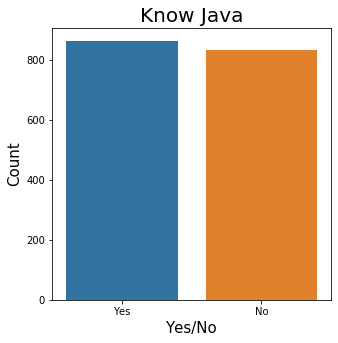

```
Counts:
```

```
Yes    864
No     833
Name: Have you worked core Java, dtype: int64
```

```python
plt.figure(figsize=(5,5))
sns.countplot(fy8['Have you worked core Java'])
plt.title('Know Java',fontsize=20)
plt.xlabel('Yes/No',fontsize=15)
plt.ylabel('Count',fontsize=15)
plt.show()
print("Counts:")
fy8['Have you worked core Java'].value_counts()
```

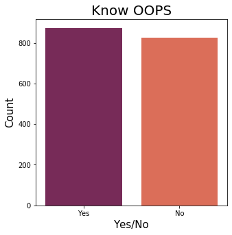

```
Counts:
```

```
Yes    873
No     824
Name: Have you studied OOP Concepts, dtype: int64
```

```python
plt.figure(figsize=(5,5))
sns.countplot(fy8['Have you studied OOP Concepts'],palette='rocket')
plt.title('Know OOPS',fontsize=20)
plt.xlabel('Yes/No',fontsize=15)
plt.ylabel('Count',fontsize=15)
plt.show()
print("Counts:")
fy8['Have you studied OOP Concepts'].value_counts()
```

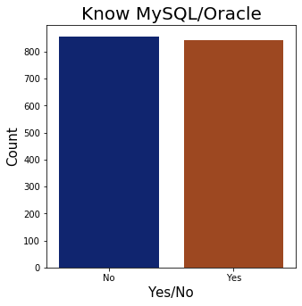

```
Counts:
```

```
No     856
Yes    841
Name: Have you worked on MySQL or Oracle database, dtype: int64
```

```python
plt.figure(figsize=(5,5))
sns.countplot(fy8['Have you worked on MySQL or Oracle database'],palette='dark')
plt.title('Know MySQL/Oracle',fontsize=20)
plt.xlabel('Yes/No',fontsize=15)
plt.ylabel('Count',fontsize=15)
plt.show()
print("Counts:")
fy8['Have you worked on MySQL or Oracle database'].value_counts()
```

# 2.e Students who applied for Digital Marketing with verbal and written communication score greater than 8

```python
DM=df[(df['Areas of interest']=='Digital Marketing ') & (df['Rate your written communication skills [1-10]']>8) & (df['Rate your verbal communication skills [1-10]']>8)]
print("Students who applied for Digital Marketing with verbal and written communication score greater than 8:",len(DM))
DM.head()
```

```
Students who applied for Digital Marketing with verbal and written communication score greater than 8: 92
```

|  | First Name | Last Name | City | State | Zip Code | DOB [DD/MM/YYYY] | Age | Gender | Email Address | Contact Number | ... | Areas of interest | Current Employment Status | Have you worked core Java | Programming Language Known other than Java (one major) | Have you worked on MySQL or Oracle database | Have you studied OOP Concepts | Rate your written communication skills [1-10] | Rate your verbal communication skills [1-10] | How Did You Hear About This Internship? | Label |
| --- | --- | --- | --- | --- | --- | --- | --- | --- | --- | --- | --- | --- | --- | --- | --- | --- | --- | --- | --- | --- | --- |
| 294 | Hazlett | Orpen | Pune | Maharashtra | 411011 | 21/11/1996 | 23 | Male | horpen86@csmonitor.com | 4522097136 | ... | Digital Marketing | Student | No | C# | Yes | Yes | 9 | 10 | Intern | eligible |
| 420 | Dolorita | Leglise | Kolhapur | Maharashtra | 416234 | 8/6/1996 | 23 | Female | dleglisebo@github.io | 8504679907 | ... | Digital Marketing | Student | Yes | PHP | No | Yes | 9 | 10 | Blog post | eligible |
| 424 | Jessa | Lightoller | NaviMumbai | Maharashtra | 400701 | 21/12/1997 | 22 | Female | jlightollerbs@hibu.com | 8671906564 | ... | Digital Marketing | Student | Yes | HTML/CSS | No | Yes | 9 | 10 | Ex/Current Employee | ineligible |
| 500 | Linet | McGuiness | Kolhapur | Maharashtra | 416119 | 15/06/2000 | 19 | Female | lmcguinessdw@rakuten.co.jp | 7118250315 | ... | Digital Marketing | Student | Yes | .Net | Yes | Yes | 9 | 10 | Newspaper | eligible |
| 588 | Elsinore | Adshed | NaviMumbai | Maharashtra | 400701 | 23/10/1997 | 22 | Female | eadshedgc@digg.com | 6446069414 | ... | Digital Marketing | Student | Yes | HTML/CSS | No | No | 10 | 10 | Newspaper | eligible |

5 rows × 29 columns

### Some insightful visualizations for students who applied for Digital Marketing with verbal and written communication score greater than 8

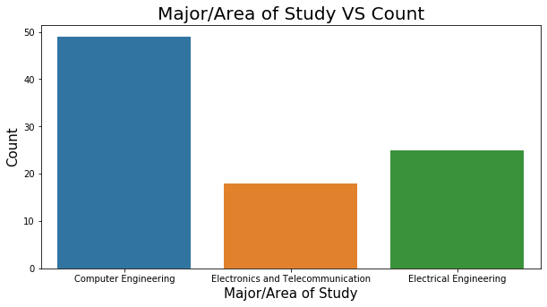

```
Counts:
```

```
Computer Engineering                 49
Electrical Engineering               25
Electronics and Telecommunication    18
Name: Major/Area of Study, dtype: int64
```

```python
plt.figure(figsize=(10,5))
sns.countplot(DM['Major/Area of Study'])
plt.title('Major/Area of Study VS Count',fontsize=20)
plt.xlabel('Major/Area of Study',fontsize=15)
plt.ylabel('Count',fontsize=15)
plt.show()
print("Counts:")
DM['Major/Area of Study'].value_counts()
```

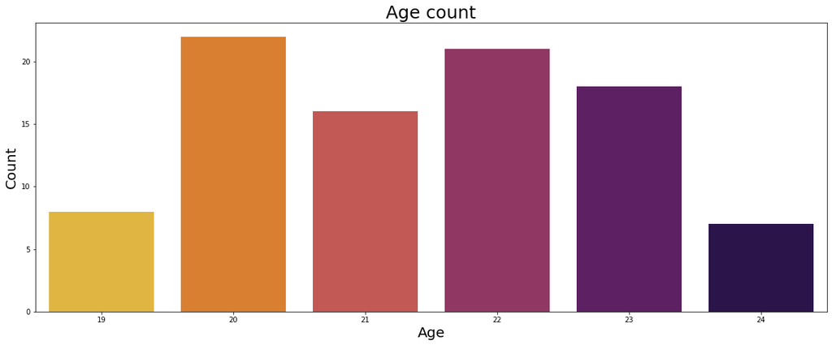

```
Counts:
```

```
20    22
22    21
23    18
21    16
19     8
24     7
Name: Age, dtype: int64
```

```python
plt.figure(figsize=(20,7.5))
sns.countplot(DM['Age'],palette='inferno_r')
plt.title('Age count',fontsize=25)
plt.xlabel('Age',fontsize=20)
plt.ylabel('Count',fontsize=20)
plt.show()
print("Counts:")
DM['Age'].value_counts()
```

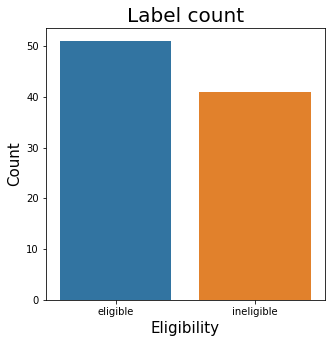

```
Counts:
```

```
eligible      51
ineligible    41
Name: Label, dtype: int64
```

```python
plt.figure(figsize=(5,5))
sns.countplot(DM['Label'])
plt.title('Label count',fontsize=20)
plt.xlabel('Eligibility',fontsize=15)
plt.ylabel('Count',fontsize=15)
plt.show()
print("Counts:")
DM['Label'].value_counts()
```

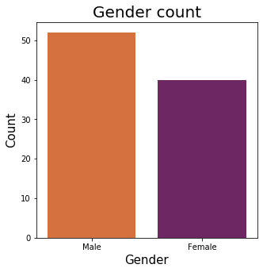

```
Counts:
```

```
Male      52
Female    40
Name: Gender, dtype: int64
```

```python
plt.figure(figsize=(5,5))
sns.countplot(DM['Gender'],palette='inferno_r')
plt.title('Gender count',fontsize=20)
plt.xlabel('Gender',fontsize=15)
plt.ylabel('Count',fontsize=15)
plt.show()
print("Counts:")
DM['Gender'].value_counts()
```

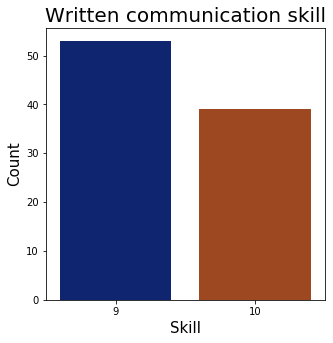

```
Counts:
```

```
9     53
10    39
Name: Rate your written communication skills [1-10], dtype: int64
```

```python
plt.figure(figsize=(5,5))
sns.countplot(DM['Rate your written communication skills [1-10]'],palette='dark')
plt.title('Written communication skill',fontsize=20)
plt.xlabel('Skill',fontsize=15)
plt.ylabel('Count',fontsize=15)
plt.show()
print("Counts:")
DM['Rate your written communication skills [1-10]'].value_counts()
```

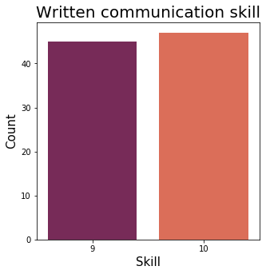

```
Counts:
```

```
9     53
10    39
Name: Rate your written communication skills [1-10], dtype: int64
```

```python
plt.figure(figsize=(5,5))
sns.countplot(DM['Rate your verbal communication skills [1-10]'],palette='rocket')
plt.title('Written communication skill',fontsize=20)
plt.xlabel('Skill',fontsize=15)
plt.ylabel('Count',fontsize=15)
plt.show()
print("Counts:")
DM['Rate your written communication skills [1-10]'].value_counts()
```

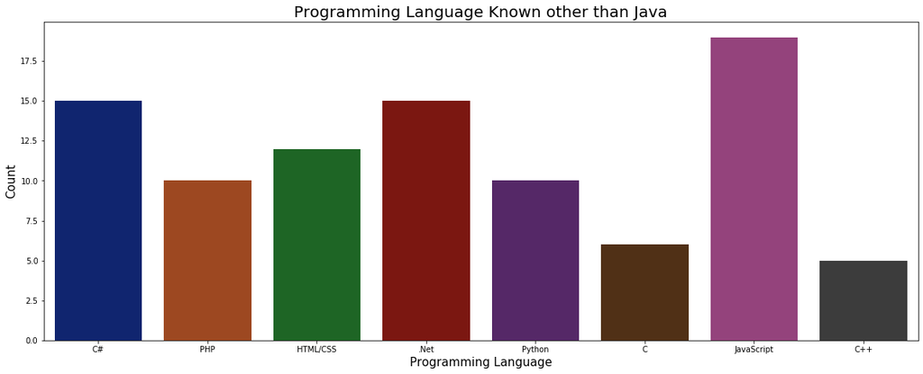

```
Counts:
```

```
JavaScript    19
.Net          15
C#            15
HTML/CSS      12
Python        10
PHP           10
C              6
C++            5
Name: Programming Language Known other than Java (one major), dtype: int64
```

```python
plt.figure(figsize=(20,7.5))
sns.countplot(DM['Programming Language Known other than Java (one major)'],palette='dark')
plt.title('Programming Language Known other than Java',fontsize=20)
plt.xlabel('Programming Language',fontsize=15)
plt.ylabel('Count',fontsize=15)
plt.show()
print("Counts:")
DM['Programming Language Known other than Java (one major)'].value_counts()
```

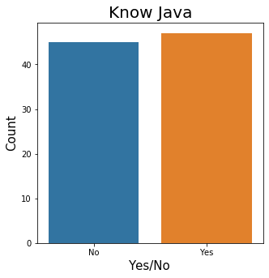

```
Counts:
```

```
Yes    47
No     45
Name: Have you worked core Java, dtype: int64
```

```python
plt.figure(figsize=(5,5))
sns.countplot(DM['Have you worked core Java'])
plt.title('Know Java',fontsize=20)
plt.xlabel('Yes/No',fontsize=15)
plt.ylabel('Count',fontsize=15)
plt.show()
print("Counts:")
DM['Have you worked core Java'].value_counts()
```

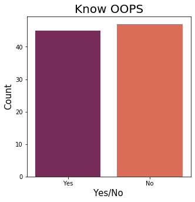

```
Counts:
```

```
No     47
Yes    45
Name: Have you studied OOP Concepts, dtype: int64
```

```python
plt.figure(figsize=(5,5))
sns.countplot(DM['Have you studied OOP Concepts'],palette='rocket')
plt.title('Know OOPS',fontsize=20)
plt.xlabel('Yes/No',fontsize=15)
plt.ylabel('Count',fontsize=15)
plt.show()
print("Counts:")
DM['Have you studied OOP Concepts'].value_counts()
```

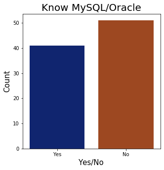

```
Counts:
```

```
No     51
Yes    41
Name: Have you worked on MySQL or Oracle database, dtype: int64
```

```python
plt.figure(figsize=(5,5))
sns.countplot(DM['Have you worked on MySQL or Oracle database'],palette='dark')
plt.title('Know MySQL/Oracle',fontsize=20)
plt.xlabel('Yes/No',fontsize=15)
plt.ylabel('Count',fontsize=15)
plt.show()
print("Counts:")
DM['Have you worked on MySQL or Oracle database'].value_counts()
```

# 2.f Year-wise and area of study wise classification of students

```python
YA=df[['Which-year are you studying in?','Areas of interest']]
YA.head()
```

|  | Which-year are you studying in? | Areas of interest |
| --- | --- | --- |
| 0 | Second-year | Artificial Intelligence |
| 1 | Fourth-year | Cloud Computing |
| 2 | Fourth-year | IoT |
| 3 | Second-year | Digital Marketing |
| 4 | First-year | Cloud Computing |

## First year students VS Areas of interest

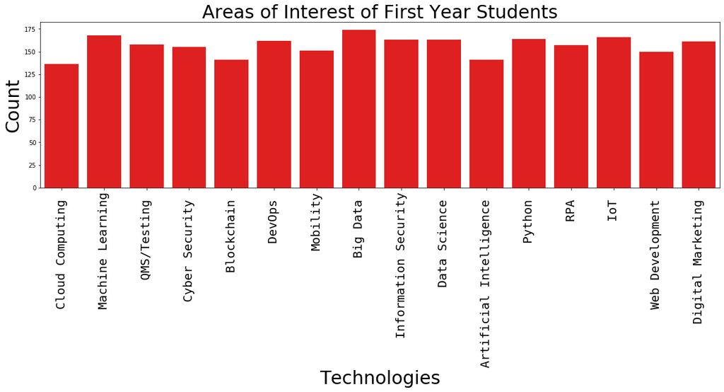

```
Count:
```

```
Big Data                    174
Machine Learning            168
IoT                         166
Python                      164
Information Security        163
Data Science                163
DevOps                      162
Digital Marketing           161
QMS/Testing                 158
RPA                         157
Cyber Security              155
Mobility                    151
Web Development             150
Artificial Intelligence     141
Blockchain                  141
Cloud Computing             136
Name: Areas of interest, dtype: int64
```

```python
YA1=YA[YA['Which-year are you studying in?']=='First-year']
plt.figure(figsize=(20,5))
sns.countplot(YA1['Areas of interest'],color='Red')
plt.xlabel('Technologies',fontsize=30)
plt.xticks(rotation=90,fontsize=20,fontname='monospace')
plt.ylabel('Count',fontsize=30)
plt.title('Areas of Interest of First Year Students',fontsize=30)
plt.show()
print('Count:')
YA1['Areas of interest'].value_counts()
```

## Second year students VS Areas of interest

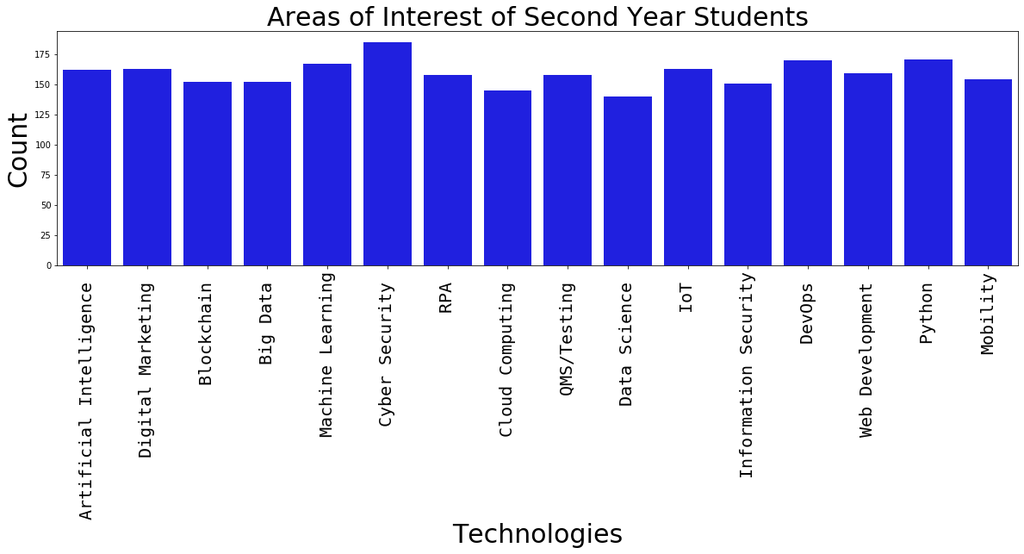

```
Count:
```

```
Cyber Security              185
Python                      171
DevOps                      170
Machine Learning            167
Digital Marketing           163
IoT                         163
Artificial Intelligence     162
Web Development             159
QMS/Testing                 158
RPA                         158
Mobility                    154
Big Data                    152
Blockchain                  152
Information Security        151
Cloud Computing             145
Data Science                140
Name: Areas of interest, dtype: int64
```

```python
YA2=YA[YA['Which-year are you studying in?']=='Second-year']
plt.figure(figsize=(20,5))
sns.countplot(YA2['Areas of interest'],color='blue')
plt.xlabel('Technologies',fontsize=30)
plt.xticks(rotation=90,fontsize=20,fontname='monospace')
plt.ylabel('Count',fontsize=30)
plt.title('Areas of Interest of Second Year Students',fontsize=30)
plt.show()
print('Count:')
YA2['Areas of interest'].value_counts()
```

## Third year students VS Areas of interest

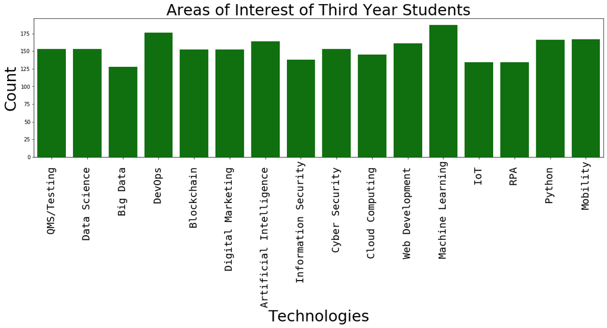

```
Count:
```

```
Machine Learning            187
DevOps                      176
Mobility                    167
Python                      166
Artificial Intelligence     164
Web Development             161
Cyber Security              153
QMS/Testing                 153
Data Science                153
Blockchain                  152
Digital Marketing           152
Cloud Computing             145
Information Security        138
RPA                         134
IoT                         134
Big Data                    128
Name: Areas of interest, dtype: int64
```

```python
YA3=YA[YA['Which-year are you studying in?']=='Third-year']
plt.figure(figsize=(20,5))
sns.countplot(YA3['Areas of interest'],color='green')
plt.xlabel('Technologies',fontsize=30)
plt.xticks(rotation=90,fontsize=20,fontname='monospace')
plt.ylabel('Count',fontsize=30)
plt.title('Areas of Interest of Third Year Students',fontsize=30)
plt.show()
print('Count:')
YA3['Areas of interest'].value_counts()
```

## Fourth year students VS Areas of interest

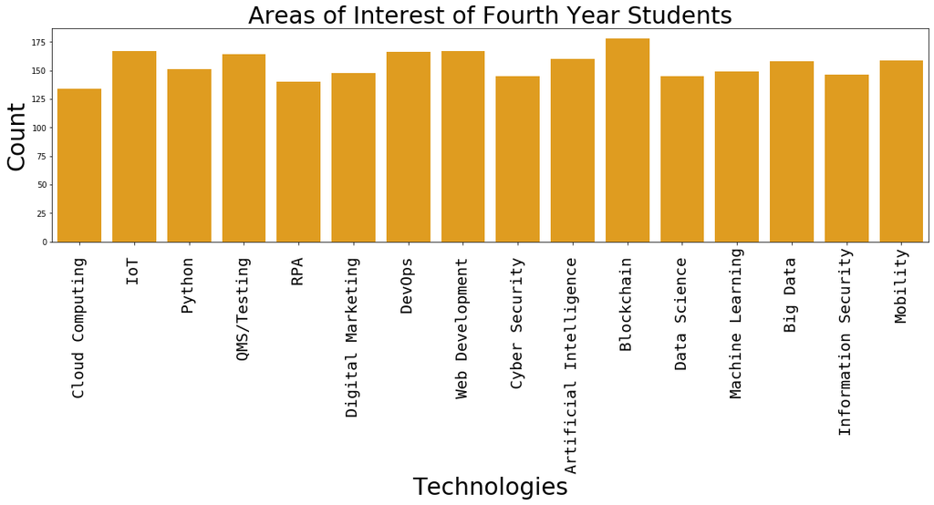

```
Count:
```

```
Blockchain                  178
Web Development             167
IoT                         167
DevOps                      166
QMS/Testing                 164
Artificial Intelligence     160
Mobility                    159
Big Data                    158
Python                      151
Machine Learning            149
Digital Marketing           148
Information Security        146
Cyber Security              145
Data Science                145
RPA                         140
Cloud Computing             134
Name: Areas of interest, dtype: int64
```

```python
YA4=YA[YA['Which-year are you studying in?']=='Fourth-year']
plt.figure(figsize=(20,5))
sns.countplot(YA4['Areas of interest'],color='orange')
plt.xlabel('Technologies',fontsize=30)
plt.xticks(rotation=90,fontsize=20,fontname='monospace')
plt.ylabel('Count',fontsize=30)
plt.title('Areas of Interest of Fourth Year Students',fontsize=30)
plt.show()
print('Count:')
YA4['Areas of interest'].value_counts()
```

## Summary of Year VS Technologies

```python
YVA={'Year':['First-year','Second-year','Third-year','Fourth-year'],'Most opted technology':['Big Data','Cyber Security','Machine Learning','Blockchain'],'Student Count':[174,185,187,178]}
dict=pd.DataFrame(YVA)
dict.set_index('Year',inplace=True)
dict
```

| Year | Most opted technology | Student Count |
| --- | --- | --- |
| First-year | Big Data | 174 |
| Second-year | Cyber Security | 185 |
| Third-year | Machine Learning | 187 |
| Fourth-year | Blockchain | 178 |

# 2.g City and college wise classification of students

### Finding unique colleges

```python
print("Unique colleges:\n\n",df['College name'].unique())
print("\nNumber of unique colleges:",len(df['College name'].unique()))
```

```
Unique colleges:

 ['DY Patil College of Engineering And Technology'
 'Vishwakarma Institute of Information Technology'
 'Vidyalankar Institute of Technology'
 'Brahmdevdada Mane Institute of Technology'
 'Rajarambapu Institute of Technology'
 'Skn Sinhgad College of Engineering'
 'Bharati Vidyapeeth College of Engineering'
 'St. Francis Institute of Technology' 'Pillai College of Engineering'
 'Ramrao Adik Institute of Technology'
 'A. C. Patil College of Engineering' 'Sinhgad College of Engineering'
 'Bharat Ratna Indira Gandhi College of Engineering'
 'K. J. Somaiya College of Engineering'
 'Thakur College Of Engineering And Technology'
 'Walchand Institute of Technology' 'Karamveer Bhauro Patil College'
 'Jayawantrao Sawant College of Engineering'
 'Pune Institute of Computer Technology' 'Rizvi College of Engineering'
 "Mahatma Gandhi Mission's College of Engineering And Technology"
 'D. Y. Patil College of Engineering'
 'Thadomal Shahani Engineering College'
 'Rajiv Gandhi Institute of Technology' 'Xavier Institute of Engineering']

Number of unique colleges: 25
```

### Finding unique cities

```python
print("Unique cities:\n\n",df['City'].unique())
print("\nNumber of unique cities:",len(df['City'].unique()))
```

```
Unique cities:

 ['Kolhapur' 'Pune' 'Mumbai' 'Solapur' 'Sangli' 'NaviMumbai']

Number of unique cities: 6
```

### Per College Count

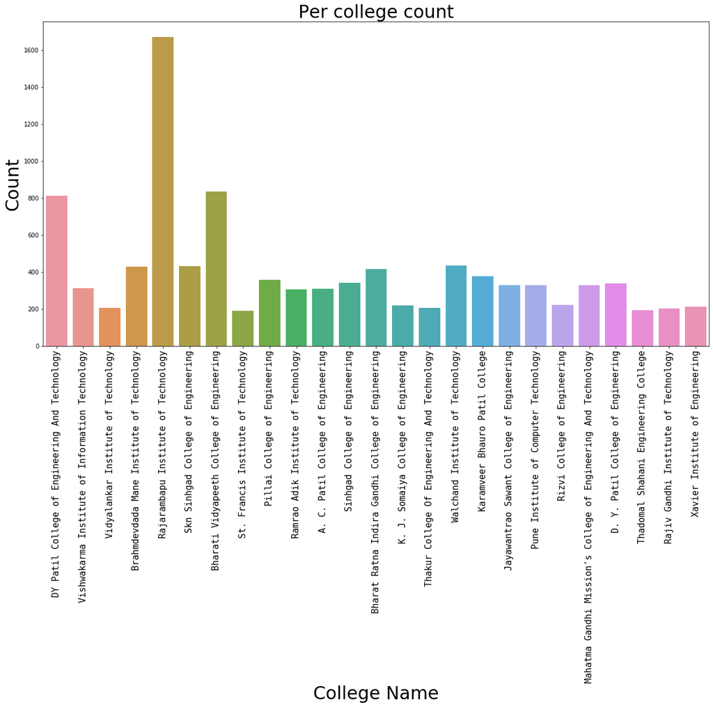

```
Count:
```

```
Rajarambapu Institute of Technology                               1670
Bharati Vidyapeeth College of Engineering                          834
DY Patil College of Engineering And Technology                     813
Walchand Institute of Technology                                   434
Skn Sinhgad College of Engineering                                 431
Brahmdevdada Mane Institute of Technology                          428
Bharat Ratna Indira Gandhi College of Engineering                  417
Karamveer Bhauro Patil College                                     378
Pillai College of Engineering                                      356
Sinhgad College of Engineering                                     340
D. Y. Patil College of Engineering                                 338
Pune Institute of Computer Technology                              329
Mahatma Gandhi Mission's College of Engineering And Technology     329
Jayawantrao Sawant College of Engineering                          327
Vishwakarma Institute of Information Technology                    313
A. C. Patil College of Engineering                                 309
Ramrao Adik Institute of Technology                                306
Rizvi College of Engineering                                       222
K. J. Somaiya College of Engineering                               220
Xavier Institute of Engineering                                    211
Vidyalankar Institute of Technology                                207
Thakur College Of Engineering And Technology                       206
Rajiv Gandhi Institute of Technology                               201
Thadomal Shahani Engineering College                               192
St. Francis Institute of Technology                                189
Name: College name, dtype: int64
```

```python
plt.figure(figsize=(20,10))
sns.countplot(df['College name'])
plt.xlabel('College Name',fontsize=30)
plt.xticks(rotation=90,fontsize=15,fontname='monospace')
plt.ylabel('Count',fontsize=30)
plt.title('Per college count',fontsize=30)
plt.show()
print('Count:')
df['College name'].value_counts()
```

```python
print("Most of the students come from the college Rajarambapu Institute of Technology:",df['College name'].value_counts().max())
print("Least of the students come from the college St. Francis Institute of Technology:",df['College name'].value_counts().min())
```

```
Most of the students come from the college Rajarambapu Institute of Technology: 1670
Least of the students come from the college St. Francis Institute of Technology: 189
```